# Diferencias temáticas entre diferentes cuentos populares del mundo

Author

Ágatha Del Olmo Tirado

Published

December 17, 2025

# Introducción

Los cuentos populares llevan siglos traspasando de generación en generación valores culturales por todo el mundo a los niños. El estudio de estos por zona geográfica es crucial porque revela la identidad cultural y los valores únicos de cada región. En este trabajo se analiza, en primer lugar, la estructura temática común de los cuentos populares mediante un modelo de Latent Dirichlet Allocation (LDA), tanto estándar como con semilla (seeded LDA). Posteriormente, se emplea un Structural Topic Model (STM) para examinar cómo la prevalencia de estos temas varía entre distintos continentes.

El objetivo principal es identificar patrones temáticos universales, evaluando si ciertos tópicos aparecen de manera consistente en diferentes regiones, así como destacar los temas característicos que reflejan particularidades culturales de cada continente.

# 1. Obtención y limpieza de los datos

En primer lugar, se obtiene una base de datos de Kaggle que contiene el texto de 2.938 cuentos procedentes de 57 culturas diferentes, que abarcan desde tradiciones españolas y catalanas hasta relatos de pueblos nativoamericanos. En este trabajo, el corpus ha sido enriquecido mediante la incorporación manual de metadatos geográficos, asignando cada relato a un continente en función de su país (o paises) de origen, con el objetivo de facilitar comparaciones temáticas entre regiones culturales.

**A tener en cuenta…**

Dado que el continente europeo presenta una mayor representatividad en el conjunto de datos en comparación con el resto de continentes, se ha optado por dividirlo en distintas zonas. No obstante, se reconoce que los demás continentes pueden ser igualmente ricos en cultura folklórica; esta diferencia se debe principalmente a la falta de información disponible en la base de datos para esas regiones.

```r
tales <- read_csv("./p42/folk_tales/folk_tales_deduplicated.csv")

dim(tales)
```

```
[1] 2938    4
```

```r
head(tales)
```

```
# A tibble: 6 × 4
  source                                                nation       title text
  <chr>                                                 <chr>        <chr> <chr>
1 https://fairytalez.com/momotaro/                      japanese     Momo… If y…
2 https://fairytalez.com/the-birdcatcher/               serbian      The … Near…
3 https://fairytalez.com/sharing-joy-and-sorrow/        german       Shar… Ther…
4 https://fairytalez.com/the-punishment-of-gangana/     french       The … Once…
5 https://fairytalez.com/the-peace-with-the-snakes/     north_ameri… The … In t…
6 https://fairytalez.com/how-the-tiger-got-his-stripes/ brazilian    How … Once…
```

```r
tales <- tales %>% select(-1)

countries <- tales %>% group_by(nation) %>% count() %>% arrange(-n)
countries
```

```
# A tibble: 58 × 2
# Groups:   nation [58]
   nation                    n
   <chr>                 <int>
 1 north_american_native   370
 2 greek                   304
 3 german                  277
 4 french                  168
 5 indian                  130
 6 english                 120
 7 italian                 105
 8 chinese                 101
 9 japanese                 88
10 nordic                   85
# ℹ 48 more rows
```

```r
#write.xlsx(countries, "./p42/countries.xlsx")

countries <- read.xlsx("./p42/countries.xlsx") %>%
  filter(!is.na(nation))

tales <- tales %>% left_join(countries) %>% select(-n)

countries %>% group_by(continent) %>% summarise(sum(n))
```

```
# A tibble: 8 × 2
  continent       `sum(n)`
  <chr>              <dbl>
1 africa               116
2 america              414
3 asia                 494
4 eastern europe       278
5 northern europe      583
6 oceania               71
7 southern europe      499
8 western europe       477
```

Aún dividiendo de esta forma los datos, siguen estando muy desbalanceados (casi 500 en el sur de Europa y unos 70 en Oceanía), así que se opta por seleccionar de forma aleatoria un subconjunto de 50 cuentos por continente, con el objetivo de evitar que las regiones con mayor representación dominen el proceso de modelización.

A continuación, cada cuento se segmenta en bloques (chunks) de aproximadamente 150 palabras para mejorar la estabilidad de los modelos LDA. La segmentación se realiza respetando, en la medida de lo posible, los límites naturales de las frases (cuando encuentra punto o signos de exclamación e interrogación). En los casos en los que el último bloque resultante contiene menos de 50 palabras, este se fusiona con el bloque anterior, con el fin de evitar documentos excesivamente cortos que podrían introducir ruido y dificultar la correcta estimación de los tópicos.

```r
set.seed(1234)
continents <- unique(countries$continent)
tales_sample <- data.frame(nation =  NULL, title = NULL, text = NULL, continent = NULL)

for (con in continents){
  tales_con <- tales %>% filter(continent == con)
  tales_pos <- sample(1:nrow(tales_con), 50)
  tales_sample <- rbind(tales_sample, tales_con[tales_pos,])
}

tales_sample_clean <- tales_sample %>%
  mutate(text = str_remove_all(text, "\\{[^\\]]*\\}")) %>%
  mutate(tale_id = row_number())

chunk_text_balanced <- function(text, tale_id, target = 150, min_last = 50) {
  sentences <- str_split(text, "(?<=[.!?])\\s+")[[1]]
  sent_lengths <- str_count(sentences, "\\S+")

  chunks <- list()
  current <- character()
  current_len <- 0
  chunk_id <- 1

  for (i in seq_along(sentences)) {
    diff_now <- abs(current_len - target)
    diff_add <- abs(current_len + sent_lengths[i] - target)

    if (current_len > 0 && diff_now <= diff_add) {
      chunks[[chunk_id]] <- tibble(
        tale_id = tale_id,
        chunk_id = chunk_id,
        text = paste(current, collapse = " ")
      )
      chunk_id <- chunk_id + 1
      current <- character()
      current_len <- 0
    }
    current <- c(current, sentences[i])
    current_len <- current_len + sent_lengths[i]
  }

  # último chunk
  chunks[[chunk_id]] <- tibble(
    tale_id = tale_id,
    chunk_id = chunk_id,
    text = paste(current, collapse = " ")
  )

  chunks_df <- bind_rows(chunks)

  if (nrow(chunks_df) > 1) {
    last_len <- str_count(chunks_df$text[nrow(chunks_df)], "\\S+")
    if (last_len < min_last) {
      chunks_df$text[nrow(chunks_df)-1] <- paste(
        chunks_df$text[nrow(chunks_df)-1],
        chunks_df$text[nrow(chunks_df)]
      )
      chunks_df <- chunks_df[-nrow(chunks_df), ]
    }
  }

  chunks_df
}

tales_chunks <- map_dfr(
  seq_along(tales_sample_clean$text),
  ~ chunk_text_balanced(text = tales_sample_clean$text[.x], tale_id = .x)
) %>%
  mutate(doc_id = paste0("tale", tale_id, "_chunk", chunk_id))
```

Con los datos completos y muestreados, se procede a la construcción del corpus textual. Para ello, se utiliza la variable que contiene el texto de los cuentos y se asigna un identificador único a cada documento.

Sobre este corpus se aplica un proceso de limpieza y normalización del texto con el objetivo de reducir el ruido y mejorar la calidad del análisis. En primer lugar, se eliminan términos comunes sin relevancia semántica mediante el uso del diccionario estándar de stopwords, complementado con una selección de palabras añadidas manualmente que aparecen con alta frecuencia en los relatos pero no aportan información temática relevante para el estudio.

Asimismo, se eliminan números, símbolos y signos de puntuación, y todo el texto se transforma a minúsculas, con el fin de evitar la duplicación artificial de términos debida a diferencias ortográficas.

```r
corpus_chunks <- corpus(tales_chunks, text_field = "text", docid_field = "doc_id")

custom_stopwords <- c(
  stopwords("en"),
  "saw","see","come","now","said","came","made","one","asked","went","go",
  "ou","de","ses","dat","told","looked","give","make","take"
)

toks_chunks <- tokens(
  corpus_chunks,
  remove_numbers = TRUE,
  remove_symbols = TRUE,
  remove_punct   = TRUE
) %>%
  tokens_remove(custom_stopwords, case_insensitive = TRUE) %>%
  tokens_tolower()
```

```r
dfm_chunks <- dfm(toks_chunks) %>%
  dfm_trim(min_termfreq = 5, min_docfreq = 3)

dfm_chunks <- dfm_chunks[rowSums(dfm_chunks) > 0, ]

meta <- tales_chunks %>%
  mutate(continent = tales_sample_clean$continent[match(tale_id, tales_sample_clean$tale_id)]) %>%
  mutate(continent = as.factor(continent))

docvars(dfm_chunks, "continent") <- meta$continent
```

Para un análisis preliminar, se examina la frecuencia de las palabras más comunes tanto a nivel global como desagregadas por grupos geográficos (continentes). Con este objetivo, se genera una nube de palabras que facilita la visualización de los términos más frecuentes para identificar de manera exploratoria posibles diferencias léxicas entre regiones.

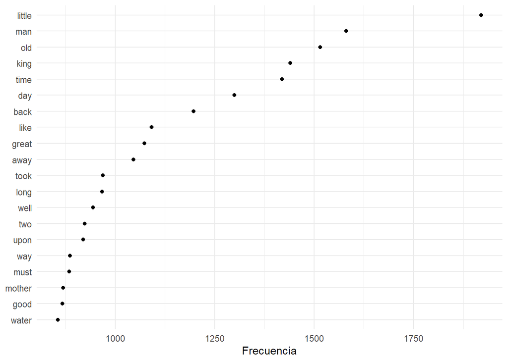

```r
set.seed(1234)

dfm_chunks %>%
  textstat_frequency(n = 20) %>%
  ggplot(aes(x = reorder(feature, frequency), y = frequency)) +
  geom_point() + coord_flip() + labs(x=NULL, y="Frecuencia") + theme_minimal()
```

La palabra más frecuente a nivel global es “little”, lo que refleja la naturaleza infantil de los textos, centrados en personajes jóvenes o pequeños, un rasgo común en todos los cuentos para niños.

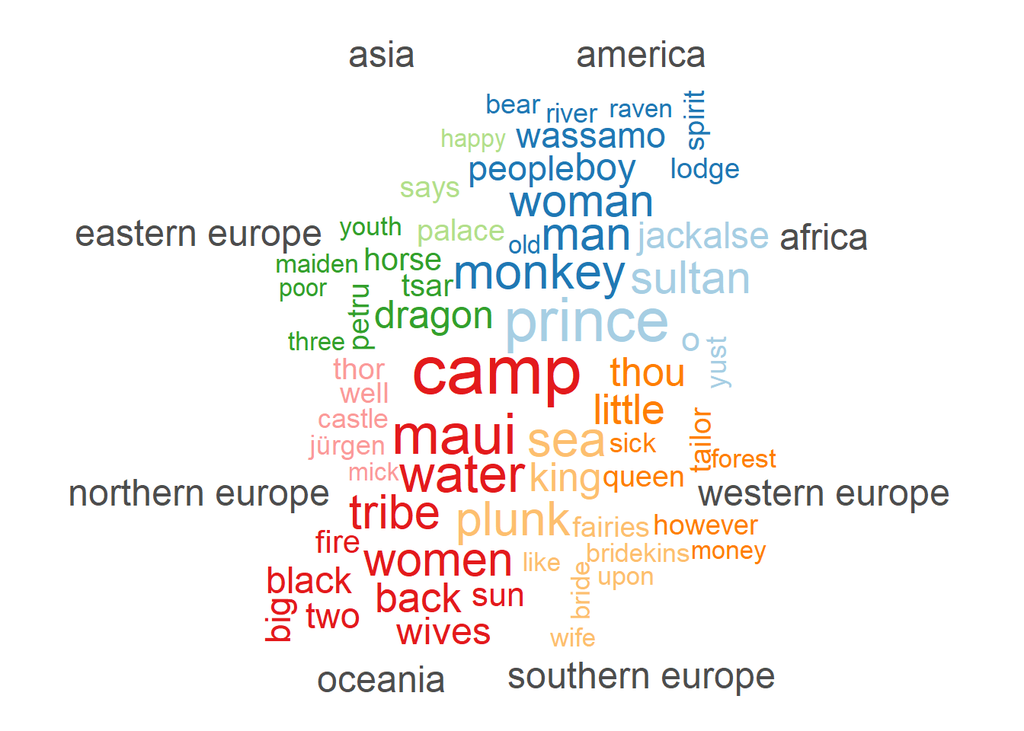

```r
words_freq_continent <- textstat_frequency(
  dfm_chunks,
  group = docvars(dfm_chunks, "continent"),
  n = 5
)

dfm_by_continent <- dfm_group(dfm_chunks, docvars(dfm_chunks, "continent"))

set.seed(1234)
textplot_wordcloud(
  dfm_by_continent,
  comparison = TRUE,
  max_words  = 80
)
```

# 2. Análisis general de tópicos mediante LDA

En este apartado se ajusta un modelo LDA estándar con el objetivo de identificar la estructura temática global del corpus, sin introducir metadatos. Para ello, la matriz documento–término previamente construida se convierte al formato de topicmodels y se ajusta un modelo LDA con K = 4 tópicos, fijando una semilla para garantizar la reproducibilidad de los resultados.

A partir del modelo estimado se extrae la matriz beta, que representa la probabilidad de cada palabra dado un tópico. Para facilitar su interpretación, se seleccionan y visualizan las cinco palabras con mayor probabilidad en cada tópico, representándolas mediante gráficos de barras.

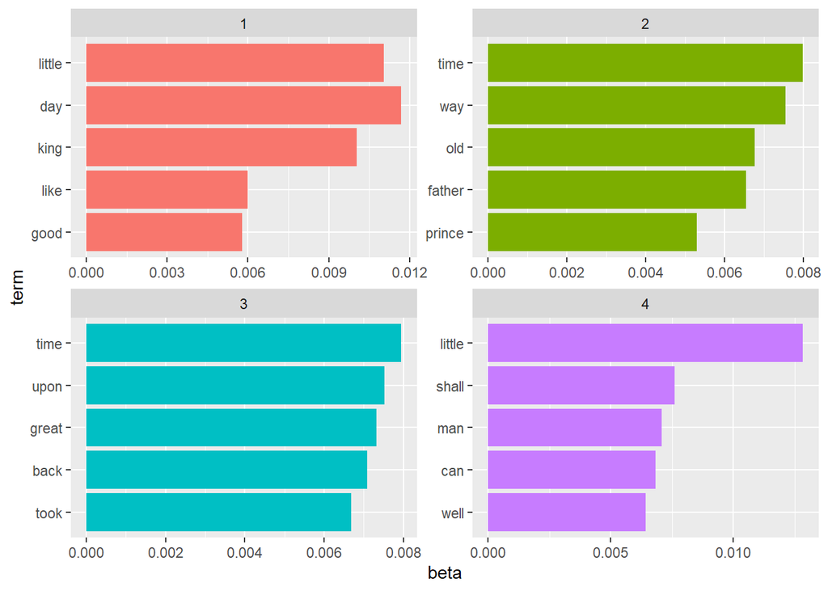

```r
DTM_chunks <- convert(dfm_chunks, to = "topicmodels")
chapters_lda <- LDA(DTM_chunks, k = 4, control = list(seed = 1234))
chapter_topics <- tidy(chapters_lda, matrix = "beta")

top_terms <- chapter_topics %>%
  group_by(topic) %>%
  slice_max(beta, n = 5) %>%
  ungroup() %>%
  arrange(topic, -beta)

top_terms %>%
  mutate(term = reorder(term, beta)) %>%
  ggplot(aes(term, beta, fill = factor(topic))) +
  geom_col(show.legend = FALSE) +
  facet_wrap(~ topic, scales = "free") +
  coord_flip()
```

- El primer tópico está marcado por palabras como little, day, king, like y good, lo que sugiere historias centradas en personajes y descripciones básicas, donde la realeza y los protagonistas jóvenes desempeñan un papel destacado.
- El segundo tópico, con términos como time, way, old, father y prince, refleja narraciones que giran en torno al paso del tiempo, los roles familiares y los personajes de autoridad, indicando la presencia de tramas lineales con viajes, lecciones o pruebas que los personajes deben afrontar.
- El tercer tópico incluye palabras como time, upon, great, back y took, mostrando un enfoque narrativo y de acción, con secuencias de eventos y aventuras.
- El cuarto tópico, representado por términos como little, shall, man, can y well, sugiere relatos donde los personajes jóvenes siguen siendo protagonistas y el lenguaje refleja consejos o moralejas que se transmiten a lo largo del cuento.

En conjunto, los tópicos del LDA clásico muestran que los cuentos infantiles comparten una estructura temática universal que combina personajes jóvenes, aventuras, fantasía y enseñanzas, aunque con cierta mezcla de fenómenos distintos entre tópicos que lo vuelve difícil de interpretar.

# 3. Análisis general de tópicos mediante LDA con semilla

Para comparar los resultados del LDA no supervisado con un enfoque guiado, en este apartado se ajusta un modelo Seeded LDA, incorporando conocimiento previo sobre los temas que se esperan encontrar en el corpus. Se definen tres áreas semánticas de interés (amor, naturaleza y fantasía), a partir de conjuntos de palabras clave representativas de cada temática, Además, se permite la existencia de tópicos residuales para capturar contenido no cubierto por las semillas y saber si se han escogido bien los temas.

A partir del modelo estimado se extrae la matriz theta, que recoge la proporción de cada tópico en cada documento. Esta información se combina con el continente asociado a cada documento, lo que permite analizar cómo varía la presencia media de los tópicos guiados entre regiones. Para ello, se calcula la proporción media de cada tópico por continente y se representa mediante un gráfico de barras apiladas.

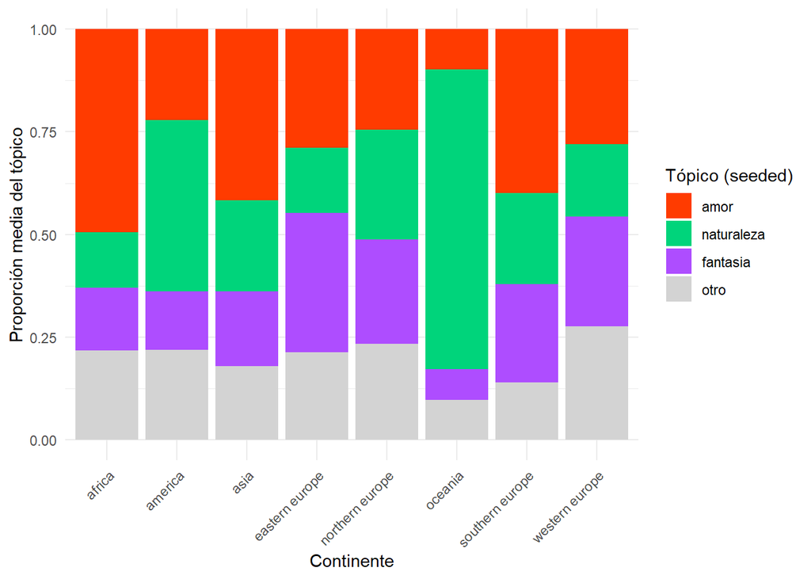

```r
dict_topics <- dictionary(list(
  amor       = c("love","heart","beautiful","pretty","marriage","wife"),
  naturaleza = c("tree","water","wind","river","mountain"),
  fantasia   = c("fairy","witch","dragon","spell","magic","knight")
))

mod_seeded <- textmodel_seededlda(dfm_chunks, dictionary = dict_topics, residual = TRUE)
theta <- as.data.frame(mod_seeded$theta)
theta$document <- rownames(theta)
theta$continent <- docvars(dfm_chunks, "continent")

if(!"other" %in% colnames(theta)) theta$other <- 0

topic_continent <- theta %>%
  group_by(continent) %>%
  summarise(across(c(amor,naturaleza,fantasia), mean, na.rm=TRUE)) %>%
  pivot_longer(cols=-continent, names_to="topic", values_to="proportion")

topic_continent <- theta %>%
  group_by(continent) %>%
  summarise(
    amor = mean(amor, na.rm = TRUE),
    naturaleza = mean(naturaleza, na.rm = TRUE),
    fantasia = mean(fantasia, na.rm = TRUE),
    otro = mean(other, na.rm = TRUE)
  ) %>%
  pivot_longer(
    cols = -continent,
    names_to = "topic",
    values_to = "proportion"
  )

topic_colors <- c(
  "amor"="#ff3b00", "naturaleza"="#00d47b", "fantasia"="#ae4dff", "otro" = "lightgrey"
)

topic_continent$topic <- factor(topic_continent$topic, levels = c("amor", "naturaleza", "fantasia", "otro"))

ggplot(topic_continent, aes(x = continent, y = proportion, fill = topic)) +
  geom_bar(stat = "identity") +
  scale_fill_manual(values = topic_colors) +
  labs(
    x = "Continente",
    y = "Proporción media del tópico",
    fill = "Tópico (seeded)"
  ) +
  theme_minimal() +
  theme(axis.text.x = element_text(angle = 45, hjust = 1))
```

Los cuentos tradicionales de Oceanía muestran una clara predominancia del tema de la naturaleza. Esto refleja la profunda conexión de las culturas oceánicas con su entorno natural, desde los océanos hasta los bosques y la fauna local.

Claramente, comparando con el clásico, el Seeded LDA permite una interpretación más dirigida de los temas, evitando la fusión excesiva de fenómenos y reduciendo la ambigüedad de los tópicos del LDA estándar. Por ejemplo, mientras que el Topic 1 y 4 del LDA clásico mezclaban personajes jóvenes con enseñanzas y realeza, el Seeded LDA separa explícitamente los temas de amor, naturaleza y fantasía, ofreciendo un resultado más interpretable. Sin embargo, aparece un tópico residual, que refleja la diversidad cultural que no se captura con las semillas.

# 4. Análisis específico por regiones mediante STM

En este bloque se realiza un análisis más avanzado incorporando metadatos de los documentos, concretamente el continente de origen de cada cuento. Para ello se utiliza el Structural Topic Model (STM), que permite modelizar la los tópicos en función de la covariable “continent”.

Primero, se convierte la matriz documento-término al formato que acepta stm y se extraen los componentes necesarios: documents, vocab y meta. Se eliminan documentos vacíos para asegurar la correcta estimación del modelo.

```r
stm_input <- convert(dfm_chunks, to = "stm")
docs  <- stm_input$documents
vocab <- stm_input$vocab
meta  <- stm_input$meta

non_empty <- lengths(docs) > 0
docs <- docs[non_empty]
meta <- meta[non_empty, ]
```

A continuación, se ajusta el modelo STM con 4 tópicos, utilizando la variable continent como covariable de prevalencia. De esta forma, el modelo aprende cómo varía la presencia de cada tópico según el continente de origen.

```r
set.seed(1234)
stm_chunks <- stm(
  documents = docs,
  vocab = vocab,
  K = 4,
  prevalence = ~ continent,
  data = meta,
  max.em.its = 75,
  init.type = "Spectral"
)

labelTopics(stm_chunks)
```

[output not shown]

- Highest Prob: Son las palabras con mayor probabilidad de aparecer en un topic. Su limitación es que pueden incluir términos muy comunes que no ayudan a diferenciar bien los temas.
- FREX (FRequency and EXclusivity): Combina la frecuencia de la palabra dentro del topic con su exclusividad respecto a los demás topics, mostrando términos distintivos que caracterizan el tema.
- Lift: Indica qué tan sorprendente es que una palabra aparezca en un topic comparado con su frecuencia global en todos los documentos, ayudando a identificar palabras únicas o raras.
- Score: Similar al lift, pero pondera la importancia relativa de la palabra dentro del topic, capturando la esencia del tema y facilitando su interpretación.

```r
findThoughts(
  stm_chunks,
  texts = tales_chunks$text,
  n = 3,
  topics = 1
)$docs[[1]] %>% substr(start=1, stop=200)
```

```
[1] "Hobyah! Hobyah! Tear down the hempstalks, eat up the old man and woman, and carry off the little girl!” But little dog Turpie barked so that the Hobyahs ran off; and the old man said, “Little dog Turp"
[2] "Tear down the hempstalks, eat up the old man and woman, and carry off the little girl!” But little dog Turpie barked so that the Hobyahs ran off; and the old man said, “Little dog Turpie barks so that"
[3] "Hobyah! Hobyah! Tear down the hempstalks, eat up the old man and woman, and carry off the little girl!” But little dog Turpie barked so that the Hobyahs ran off; and the old man said, “Little dog Turp"
```

Topic 2: Realeza y romance: Palabras clave: sultan, aladdin, princess, prince, palace. Refleja relatos de palacios, príncipes y princesas, mezclando elementos del folklore europeo y oriental. Los cuentos de este topic suelen girar en torno a historias de amor, aventuras heroicas y narrativas de realeza.

```r
findThoughts(
  stm_chunks,
  texts = tales_chunks$text,
  n = 3,
  topics = 2
)$docs[[1]] %>% substr(start=1, stop=200)
```

```
[1] "I gladly yield to her the precedence and title of Queen in recognition of the debt of gratitude which I owe her.”King Armanos heard the princess with surprise and admiration, then, turning to Camaralz"
[2] "But, sire, I can only accept such an alliance if you give me your promise to assist me with your counsels.”The marriage being thus arranged, the ceremony was fixed for the following day, and the princ"
[3] "However, he would not have recourse to extreme measures, so he said: “I do not wish to force you; I will give you time to reflect, but remember that such a step is necessary, for a prince such as you "
```

```r
findThoughts(
  stm_chunks,
  texts = tales_chunks$text,
  n = 3,
  topics = 3
)$docs[[1]] %>% substr(start=1, stop=200)
```

```
[1] "Goomblegubbon the bustard, his two wives, Beeargah the hawk, and Ouyan the curlew, with the two children of Beeargah, had their camps right away in the bush; their only water supply was a small dungle"
[2] "He saw the seven sisters all start out with their yam sticks in hand. He followed at a distance, taking care not to be seen. He saw them stop by the nests of some flying ants. With their yam sticks th"
[3] "‘You’ll ha’ to come down out o’ dat tree sometime, an’ here I’ll be ready.’“‘Dat’s yust all right,’ ses Leelikie. ‘My daddy an’ de rest o’ de baviyàans is comin’ dis way in a bit. Den p’r’aps you’ll s"
```

Topic 4: Naturaleza y mitología: Palabras clave: thor, maui, æsir, sea, dragon. Agrupa cuentos donde la naturaleza y la mitología son protagonistas, combinando héroes, dioses y criaturas míticas. Este topic es más frecuente en el norte de Europa, reflejando la relación de estos cuentos con el entorno natural y los mitos locales.

```r
findThoughts(
  stm_chunks,
  texts = tales_chunks$text,
  n = 3,
  topics = 4
)$docs[[1]] %>% substr(start=1, stop=200)
```

```
[1] "Ægir was the ruler of the ocean, and his home was deep down below the tossing waves, where the water is calm and still. There was his beautiful palace, in the wonderful coral caves; its walls all hung"
[2] "There was his beautiful palace, in the wonderful coral caves; its walls all hung with bright-colored seaweeds, and the floor of white, sparkling coral sand. Such wonderful sea-plants grew all about, a"
[3] "In the waterfalls, the stromkarls sang; and sometimes, under ground, they could hear the hill-trolls praying Odin to give them souls. Sometimes they found beautiful grassy places where grew the fair w"
```

Finalmente, para confirmar las suposiciones de diferencias de regiones por tópico, se estima el efecto de la covariable continent sobre la prevalencia de cada tópico con estimateEffect para analizar de forma cuantitativa cómo varía la presencia de los temas según la región comparando con África, que actúa como referencia:

```r
meta$rating <- as.factor(meta$continent)
prep <- estimateEffect(1:4 ~ continent, stm_chunks, meta = meta, uncertainty = "Global")
summary(prep, topics = 1:4)
```

```
Call:
estimateEffect(formula = 1:4 ~ continent, stmobj = stm_chunks,
    metadata = meta, uncertainty = "Global")


Topic 1:

Coefficients:
                          Estimate Std. Error t value Pr(>|t|)
(Intercept)               0.125821   0.008686  14.485  < 2e-16 ***
continentamerica          0.133460   0.016906   7.894 3.61e-15 ***
continentasia             0.140966   0.014763   9.549  < 2e-16 ***
continenteastern europe   0.301509   0.013306  22.659  < 2e-16 ***
continentnorthern europe  0.216605   0.014318  15.129  < 2e-16 ***
continentoceania         -0.032726   0.016017  -2.043   0.0411 *
continentsouthern europe  0.131553   0.017349   7.583 4.05e-14 ***
continentwestern europe   0.343387   0.016080  21.354  < 2e-16 ***
---
Signif. codes:  0 '***' 0.001 '**' 0.01 '*' 0.05 '.' 0.1 ' ' 1


Topic 2:

Coefficients:
                         Estimate Std. Error t value Pr(>|t|)
(Intercept)               0.51798    0.01003  51.666  < 2e-16 ***
continentamerica         -0.35856    0.01761 -20.365  < 2e-16 ***
continentasia            -0.12256    0.01595  -7.685 1.86e-14 ***
continenteastern europe  -0.25560    0.01408 -18.153  < 2e-16 ***
continentnorthern europe -0.29254    0.01485 -19.693  < 2e-16 ***
continentoceania         -0.47526    0.01708 -27.831  < 2e-16 ***
continentsouthern europe -0.10377    0.01834  -5.657 1.63e-08 ***
continentwestern europe  -0.27453    0.01657 -16.568  < 2e-16 ***
---
Signif. codes:  0 '***' 0.001 '**' 0.01 '*' 0.05 '.' 0.1 ' ' 1


Topic 3:

Coefficients:
```

[output cut: 12 more lines]

```

Topic 4:

Coefficients:
                         Estimate Std. Error t value Pr(>|t|)
(Intercept)              0.148941   0.008881  16.771  < 2e-16 ***
continentamerica         0.192126   0.017727  10.838  < 2e-16 ***
continentasia            0.086390   0.014349   6.021 1.87e-09 ***
continenteastern europe  0.143535   0.012842  11.177  < 2e-16 ***
continentnorthern europe 0.223762   0.014824  15.094  < 2e-16 ***
continentoceania         0.119668   0.017693   6.764 1.51e-11 ***
continentsouthern europe 0.137353   0.017358   7.913 3.11e-15 ***
continentwestern europe  0.043475   0.015831   2.746  0.00605 **
---
Signif. codes:  0 '***' 0.001 '**' 0.01 '*' 0.05 '.' 0.1 ' ' 1
```

El Topic 1, que representa cuentos con personajes comunes y folklore del norte de Europa, muestra coeficientes muy positivos y significativos para Europa del Este (0.30), Europa Occidental (0.34) y Europa del Norte (0.21), lo que indica que estos relatos son mucho más frecuentes en estas regiones que en África. Esto confirma que los cuentos centrados en personajes cotidianos que interactúan con criaturas míticas locales son típicos del folklore europeo del norte y este. En Oceanía, en cambio, la prevalencia de este tema es ligeramente negativa, mostrando que es menos relevante allí.

El Topic 2, asociado a la realeza y al romance, tiene un intercepto alto, pero todos los coeficientes continentales son negativos, siendo especialmente bajos en Oceanía (-0.47), América (-0.36) y Europa del Norte (-0.29). Esto sugiere que, comparado con África, los cuentos de palacios, príncipes y princesas son menos frecuentes en todos los otros continentes, reflejando una concentración de este tipo de relatos en las tradiciones africanas.

El Topic 3, que incluye aventuras con animales y pruebas, tiene coeficientes positivos en Oceanía (0.39) y América (0.03), mientras que en Europa y Asia los coeficientes son negativos. Esto indica que los cuentos centrados en animales y aventuras son más comunes en Oceanía y América, y relativamente menos frecuentes en Europa y Asia. Estos relatos reflejan la importancia de los animales como símbolos morales y la narrativa de viajes en estas regiones.

En conjunto, los resultados muestran un patrón claro: Europa del Norte, Este y Oeste destacan en folklore y personajes cotidianos; Oceanía y América privilegian aventuras con animales y temas de naturaleza; y África, como referencia, aparece como un punto de comparación donde los cuentos de realeza y romance son relativamente frecuentes. La naturaleza y la mitología se distribuyen de manera más homogénea, siendo un tema globalmente presente en todas las regiones.

# 5. Conclusiones

Al comparar los tres enfoques (LDA clásico, Seeded LDA y STM), la decisión sobre cuál ofrece una estructura temática más interpretable y útil debe basarse principalmente en la lectura cualitativa de las matrices beta (palabras por tópico) y theta (proporción de tópicos por documento).

El LDA clásico identifica automáticamente cuatro tópicos sin guía externa. Aunque captura la estructura general del corpus, algunos tópicos resultan híbridos o poco diferenciados. Esto refleja que las palabras frecuentes se mezclan entre varios temas, dificultando asignarles etiquetas claras. En términos métricos, puede mostrar coherencia moderada, pero la interpretación cualitativa revela ambigüedad en varios tópicos.

El Seeded LDA, al incorporar palabras clave predefinidas para amor, naturaleza y folklore, genera tópicos más claros y directamente interpretables. Las matrices beta muestran palabras muy distintivas por tema, lo que facilita asignar etiquetas significativas. Asimismo, la matriz theta muestra cómo se distribuye cada cuento entre estos temas, revelando patrones regionales consistentes. El principal inconveniente es la aparición de un tópico residual, que indica que no todo el contenido encaja en las semillas; sin embargo, esto aporta información sobre la diversidad cultural que escapa a los temas previstos.

El STM, al incluir la covariable continente, añade una dimensión extra: no solo identifica tópicos claros, sino que también muestra cómo varía su prevalencia según la región, incorporando información contextual. Esto enriquece la interpretabilidad para estudios comparativos y ayuda a identificar tópicos híbridos o residuales específicos de cada continente.

En resumen, para este dominio de cuentos tradicionales de distintas regiones, el Seeded LDA y el STM son más útiles que el LDA clásico. El Seeded LDA proporciona una estructura temática clara y directamente interpretable, mientras que el STM añade la dimensión regional, ofreciendo un análisis más rico y contextualizado.

En general, los resultados de los diferentes modelos de análisis de tópicos muestran que, aunque existen patrones culturales específicos, los cuentos tradicionales presentan también elementos temáticos universales. Sobre todo la presencia recurrente de personajes jóvenes se observa en todos los continentes, lo que confirma que ciertos motivos narrativos son compartidos globalmente.

Al mismo tiempo, los análisis con Seeded LDA y STM revelan variaciones regionales significativas: Oceanía y América destacan en relatos centrados en la naturaleza y la fauna, Europa en el folklore y, en el sur, en historias de amor, mientras que África y Asia priorizan narrativas de amor. Estas diferencias reflejan cómo las culturas adaptan los elementos universales a su contexto, incorporando personajes míticos locales, entornos naturales o valores sociales específicos.

# 6. Futuras líneas de investigación y posibles mejoras

Una posible mejora sería ampliar el corpus con más cuentos y más diversificados, permitiendo un análisis más fino por región. Por ejemplo, sería útil tener suficientes para poder separar cuentos de pueblos nativos norteamericanos de los canadienses, en lugar de agruparlos, para captar mejor las particularidades culturales de cada grupo.

También sería relevante tener en cuenta el estilo de escritura de cada tradición, tanto para minimizar su efecto en un análisis temático como para estudiarlo de manera independiente. Por ejemplo, parece que los cuentos europeos tienden a ser más sofisticados y poéticos, mientras que los relatos de los pueblos nativos americanos utilizan un lenguaje mucho más sencillo y directo. Analizar estas diferencias estilísticas podría aportar información sobre la forma en que las culturas transmiten sus valores y su folklore.

Otra línea de investigación interesante sería explorar cómo los temas predominantes en los cuentos podrían influir en las creencias y comportamientos de cada cultura. Por ejemplo, en Asia y África, donde el amor es el tema más común, podría estudiarse si estos cuentos fomentan valores como el matrimonio y la formación de familia. En Oceanía, donde predomina la naturaleza, podrían investigarse posibles efectos sobre la conciencia ambiental o la relación con el medio ambiente, incluyendo temas contemporáneos como la contaminación.

En conjunto, estas mejoras permitirían no solo refinar el análisis temático, sino también conectar los patrones narrativos con aspectos culturales, sociales y educativos de cada región.